# ABQ Daily Report

Connor Whalen, Gabby Commisso, Katie Leslie, Chelsea Wood

2025-06-10

# Description

Summary log of leadership and decision activities conducted by leadership team at the University of New Mexico during our 2025 summer CAREER parasite lab work in Albuquerque, New Mexico.

# Initial Selection Procedure

### Link to Google Spreadsheet

[Lot selection and tracking spreadsheet](https://docs.google.com/spreadsheets/d/1waDMf6cTmtEeaT_14-uCFXRKaHarc8dxyh9Y7yJx9l0/edit?pli=1&gid=486468529#gid=486468529)

### 6/11/25

Connor sent resampling lots and numbers to Chelsea who replaced them in the spreadsheet on 6/12/25. The lots are as follows: MSB:Fish:5253 Gambusia affinis MSB:Fish:5247 Hybognathus amarus MSB:Fish:5803 Hybognathus amarus MSB:Fish:11156 Pimephales promelas MSB:Fish:11167 Pimephales promelas MSB:Fish:1171 Hybognathus amarus MSB:Fish:1150 Hybognathus amarus MSB:Fish:3651 Pimephales promelas MSB:Fish:30386 Gambusia affinis MSB:Fish:30239 Pimephales promelas MSB:Fish:19232 Gambusia affinis MSB:Fish:73766 Hybognathus amarus MSB:Fish:77030 Hybognathus amarus MSB:Fish:77021 Hybognathus amarus MSB:Fish:94735 Pimephales promelas

### 6/12/25

Connor found two more lots that need to be resampled. Went back through the code file specimen_tallies.R and checked for resampling options for both GAMAFF 1068 and HYBAMA 1162. Neither of them are able to be replaced as there are no more available lots in the collection for their respective CI category and years. Connor made note of this in the spreadsheet The lots are as follows: MSB:Fish:1068 Gambusia affinis MSB:Fish:1162 Hybognathus amarus

### 6/13/25

Connor found more lots that needed to be resampled. Connor also went through the list of missing lots and has identified the majority of those that were not found initially, though some are still missing. We have 1 lot that needs to be either found or resampled to send in the shipment to Katie, as well as a few other lots that are missing. The list of missing lots is here: MSB:Fish:7917 Pimephales promelas MSB:Fish:18794 Pimephales promelas MSB:Fish:334 Gambusia affinis MSB:Fish:1122 Hybognathus amarus MSB:Fish:24944 Hybognathus amarus MSB:Fish:39103 Hybognathus amarus

### Check at the outset to make sure that we are on track to reach our goals with the lots that we have in hand

Install required packages

Load required packages

First, bring in all of the meta-data you need to unite with your dissection data

```r
meta_data <- read.csv(here("data", "all_lots_okay_to_dissect.csv"))
meta_data$combo<-paste(meta_data$CI,meta_data$decade,sep="_")
```

Then bring in the dataset

```r
lots<-read.csv(here("data", "final_lots_2024.12.30_WITH_SHIP_REQUEST_missing_lots_replaced.csv"))
length(lots$CatalogNumber)
```

```
## [1] 219
```

```r
lots_in_hand <- lots %>%
filter(ready!= "SKIP")

length(lots_in_hand$CatalogNumber)
```

```
## [1] 203
```

```r
219-203
```

```
## [1] 16
```

Now merge lot data with meta-data (all.x makes sure that you keep all individual fish from the same lot, even though they have the same catalog number).

```r
lots_with_metadata<-merge(lots_in_hand, meta_data, by.x = "CatalogNumber", by.y = "CatalogNumber", all.x = TRUE)
length(lots_with_metadata$CatalogNumber)
```

```
## [1] 203
```

Plot to see where the dissected fish fall

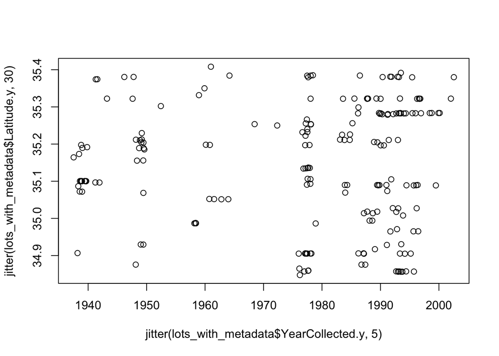

```r
plot(jitter(lots_with_metadata$Latitude.y,30)~jitter(lots_with_metadata$YearCollected.y,5))
```

Actual level of replication

```r
lots_actual<-lots_with_metadata %>%
  group_by(ScientificName.x,combo.x) %>%
  summarize(actual = n())

View(lots_actual)

count_up<-lots_with_metadata %>%
  group_by(ScientificName.x) %>%
  summarize(actual = 5*n())
```

Tally up everything that is not being shipped

```r
dissect_here<-lots_with_metadata %>%
filter(SHIP_REQUEST != "x") %>%
  group_by(ScientificName.x) %>%
  summarize(actual = 5*n())

sum(dissect_here$actual)
```

```
## [1] 825
```

I checked lots_actual against the database, and it looks like we have pulled everything it is possible to pull! The only chance of filling in gaps is finding uncatalogued specimens. I’ll take a quick look and see if any of the old jars are by chance not cataloged. - No uncatalogued lots to be found!

### Code for doing daily checks

The purpose of this script is to allow dissectors to quickly assess levels of replication in each category (i.e., before-impact, after-impact, before-control, after-control) during dissections, so that we can adjust lot selection on the fly if need be. We also want to make sure that fish body size range is constant across decades, that latitudes sampled in early days are the same as the latitudes sampled later, and that we are on track to hit our dissection goals.

### First, bring in all of the meta-data you need to unite with your dissection data

```r
meta_data<-read.csv(here("data", "all_lots_okay_to_dissect.csv"))
meta_data$combo<-paste(meta_data$CI,meta_data$decade,sep="_")
View(meta_data)
```

# HYBAMA

Download latest file

```r
hyb_ama_today<-read.csv(here("data", "HYBAMA Data_2025.07.03.csv"))

length(hyb_ama_today$CatalogNumber)
```

```
## [1] 210
```

Now merge dissection data with meta-data (all.x makes sure that you keep all individual fish from the same lot, even though they have the same catalog number).

```r
hyb_ama_with_metadata<-merge(hyb_ama_today, meta_data, by = "CatalogNumber", all.x = TRUE)
length(hyb_ama_with_metadata$CatalogNumber)
```

```
## [1] 210
```

```r
View(hyb_ama_with_metadata)
```

Plot to see where the dissected fish fall

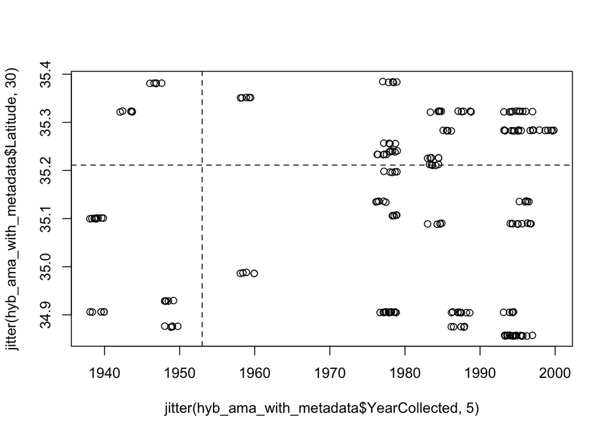

```
## integer(0)
```

```r
plot(jitter(hyb_ama_with_metadata$Latitude,30)~jitter(hyb_ama_with_metadata$YearCollected,5))+abline(a = 35.211106, b = 0, lty = 2)+abline(v = 1953, lty = 2)
```

Desired level of replication

```r
hyb_ama_desired<-read.csv(here("data", "hyb_ama_goal.csv"))
hyb_ama_desired<-hyb_ama_desired[,-1]
colnames(hyb_ama_desired)[2]<-"n_lots_desired"
hyb_ama_desired$individual_fish_desired<-hyb_ama_desired$n_lots_desired*5
```

Actual level of replication

```r
hyb_ama_actual<-hyb_ama_with_metadata %>%
  group_by(combo) %>%
  summarize(actual = n())
```

Merge desired and actual

```r
hyb_ama_remaining<-merge(hyb_ama_desired, hyb_ama_actual, by.x = "combo", by.y = "combo", all.x = TRUE, all.y = TRUE)
```

Calculate how many you have left

```r
hyb_ama_remaining$to_go<-(hyb_ama_remaining$individual_fish_desired-ifelse(is.na(hyb_ama_remaining$actual),0,hyb_ama_remaining$actual))
sum(hyb_ama_remaining$actual,na.rm=T)
```

```
## [1] 210
```

```r
sum(hyb_ama_remaining$to_go,na.rm=T)
```

```
## [1] 85
```

Check that body size is invariant through time

```r
summary(glm(hyb_ama_with_metadata$Total_Length_mm~hyb_ama_with_metadata$YearCollected))
```

```
##
## Call:
## glm(formula = hyb_ama_with_metadata$Total_Length_mm ~ hyb_ama_with_metadata$YearCollected)
##
## Coefficients:
##                                      Estimate Std. Error t value Pr(>|t|)
## (Intercept)                         189.09035   91.75362   2.061   0.0406 *
## hyb_ama_with_metadata$YearCollected  -0.06857    0.04637  -1.479   0.1407
## ---
## Signif. codes:  0 '***' 0.001 '**' 0.01 '*' 0.05 '.' 0.1 ' ' 1
##
## (Dispersion parameter for gaussian family taken to be 149.6049)
##
##     Null deviance: 31445  on 209  degrees of freedom
## Residual deviance: 31118  on 208  degrees of freedom
## AIC: 1651.6
##
## Number of Fisher Scoring iterations: 2
```

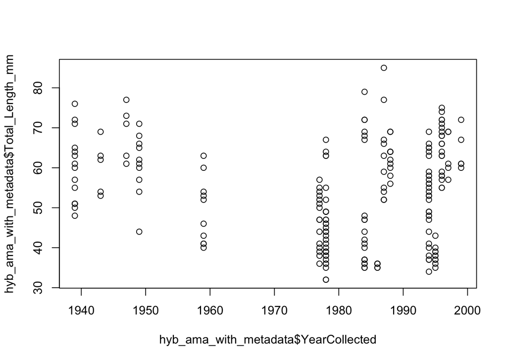

```r
plot(hyb_ama_with_metadata$Total_Length_mm~hyb_ama_with_metadata$YearCollected)
```

```r
summary(glm(hyb_ama_with_metadata$Total_Length_mm~hyb_ama_with_metadata$Latitude))
```

```
##
## Call:
## glm(formula = hyb_ama_with_metadata$Total_Length_mm ~ hyb_ama_with_metadata$Latitude)
##
## Coefficients:
##                                Estimate Std. Error t value Pr(>|t|)
## (Intercept)                     342.725    163.450   2.097   0.0372 *
## hyb_ama_with_metadata$Latitude   -8.239      4.655  -1.770   0.0782 .
## ---
## Signif. codes:  0 '***' 0.001 '**' 0.01 '*' 0.05 '.' 0.1 ' ' 1
##
## (Dispersion parameter for gaussian family taken to be 148.9343)
##
##     Null deviance: 31445  on 209  degrees of freedom
## Residual deviance: 30978  on 208  degrees of freedom
## AIC: 1650.7
##
## Number of Fisher Scoring iterations: 2
```

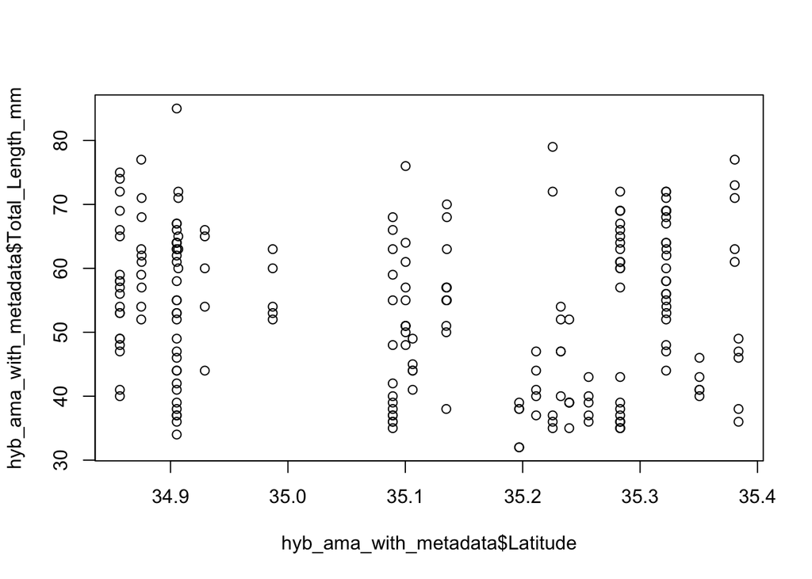

```r
plot(hyb_ama_with_metadata$Total_Length_mm~hyb_ama_with_metadata$Latitude)
```

Create a matrix that shows how many fish you are finishing per day

```r
hyb_ama_dailies<-hyb_ama_with_metadata %>%
  group_by(Completion_Date) %>%
  summarize(actual = n())
```

Need to resample a lot of hybama 6/24/25: Lot 5272 does not have big enough fish, and there are no remaining lots for control 1981-1990, so we will skip this lot.

### 6/30/25

Replace HYBAMA MSB:Fish:18820 – impact_1991to2000: replace with MSB:Fish:19001 — too small, replace with MSB:Fish:30075

### 7/2/25

Replace HYBAMA MSB:Fish:30401 (too few fish in the jar) – impact_1991to2000 replace with MSB:Fish:20390

# GAMAFF

Download latest file

```r
hyb_ama_today<-read.csv(here("data", "HYBAMA Data_2025.07.03.csv"))

length(hyb_ama_today$CatalogNumber)
```

```
## [1] 210
```

Now merge dissection data with meta-data (all.x makes sure that you keep all individual fish from the same lot, even though they have the same catalog number).

```r
hyb_ama_with_metadata<-merge(hyb_ama_today, meta_data, by = "CatalogNumber", all.x = TRUE)
length(hyb_ama_with_metadata$CatalogNumber)
```

```
## [1] 210
```

```r
View(hyb_ama_with_metadata)
```

Plot to see where the dissected fish fall

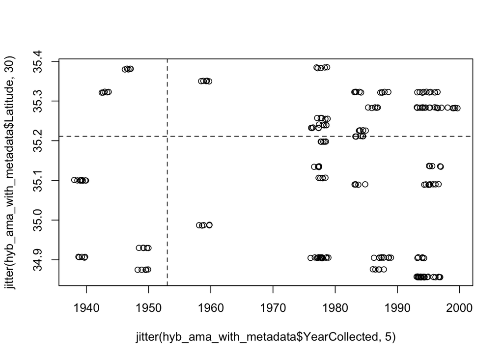

```
## integer(0)
```

```r
plot(jitter(hyb_ama_with_metadata$Latitude,30)~jitter(hyb_ama_with_metadata$YearCollected,5))+abline(a = 35.211106, b = 0, lty = 2)+abline(v = 1953, lty = 2)
```

Desired level of replication

```r
gam_aff_desired<-read.csv(here("data", "gam_aff_goal.csv"))
gam_aff_desired<-gam_aff_desired[,-1]
colnames(gam_aff_desired)[2]<-"n_lots_desired"
gam_aff_desired$individual_fish_desired<-gam_aff_desired$n_lots_desired*5
```

Actual level of replication

```r
hyb_ama_actual<-hyb_ama_with_metadata %>%
  group_by(combo) %>%
  summarize(actual = n())
```

Merge desired and actual

```r
hyb_ama_remaining<-merge(hyb_ama_desired, hyb_ama_actual, by.x = "combo", by.y = "combo", all.x = TRUE, all.y = TRUE)
```

Calculate how many you have left

```r
hyb_ama_remaining$to_go<-(hyb_ama_remaining$individual_fish_desired-ifelse(is.na(hyb_ama_remaining$actual),0,hyb_ama_remaining$actual))
sum(hyb_ama_remaining$actual,na.rm=T)
```

```
## [1] 210
```

```r
sum(hyb_ama_remaining$to_go,na.rm=T)
```

```
## [1] 85
```

Check that body size is invariant through time

```r
summary(glm(hyb_ama_with_metadata$Total_Length_mm~hyb_ama_with_metadata$YearCollected))
```

```
##
## Call:
## glm(formula = hyb_ama_with_metadata$Total_Length_mm ~ hyb_ama_with_metadata$YearCollected)
##
## Coefficients:
##                                      Estimate Std. Error t value Pr(>|t|)
## (Intercept)                         189.09035   91.75362   2.061   0.0406 *
## hyb_ama_with_metadata$YearCollected  -0.06857    0.04637  -1.479   0.1407
## ---
## Signif. codes:  0 '***' 0.001 '**' 0.01 '*' 0.05 '.' 0.1 ' ' 1
##
## (Dispersion parameter for gaussian family taken to be 149.6049)
##
##     Null deviance: 31445  on 209  degrees of freedom
## Residual deviance: 31118  on 208  degrees of freedom
## AIC: 1651.6
##
## Number of Fisher Scoring iterations: 2
```

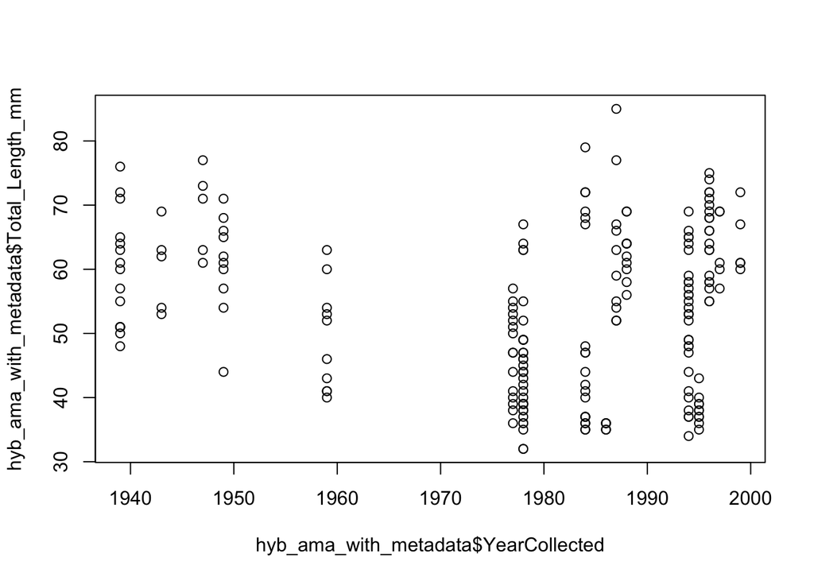

```r
plot(hyb_ama_with_metadata$Total_Length_mm~hyb_ama_with_metadata$YearCollected)
```

```r
summary(glm(hyb_ama_with_metadata$Total_Length_mm~hyb_ama_with_metadata$Latitude))
```

```
##
## Call:
## glm(formula = hyb_ama_with_metadata$Total_Length_mm ~ hyb_ama_with_metadata$Latitude)
##
## Coefficients:
##                                Estimate Std. Error t value Pr(>|t|)
## (Intercept)                     342.725    163.450   2.097   0.0372 *
## hyb_ama_with_metadata$Latitude   -8.239      4.655  -1.770   0.0782 .
## ---
## Signif. codes:  0 '***' 0.001 '**' 0.01 '*' 0.05 '.' 0.1 ' ' 1
##
## (Dispersion parameter for gaussian family taken to be 148.9343)
##
##     Null deviance: 31445  on 209  degrees of freedom
## Residual deviance: 30978  on 208  degrees of freedom
## AIC: 1650.7
##
## Number of Fisher Scoring iterations: 2
```

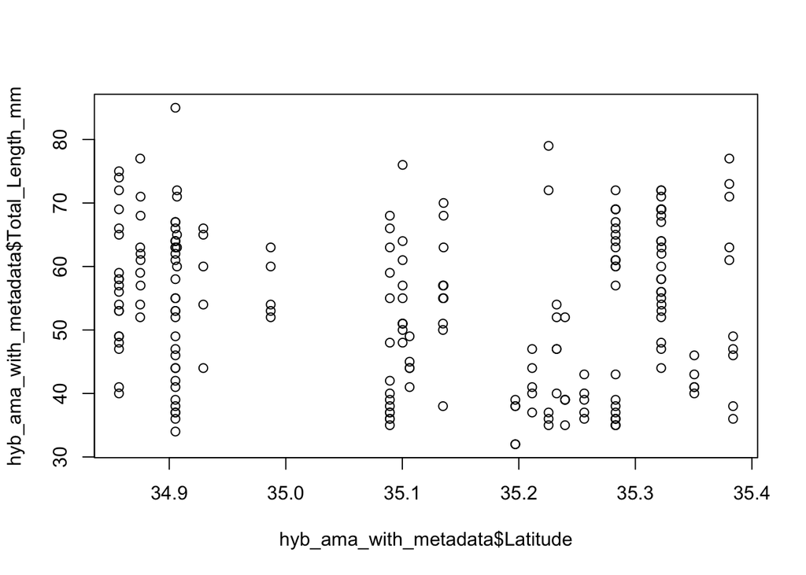

```r
plot(hyb_ama_with_metadata$Total_Length_mm~hyb_ama_with_metadata$Latitude)
```

Create a matrix that shows how many fish you are finishing per day

```r
hyb_ama_dailies<-hyb_ama_with_metadata %>%
  group_by(Completion_Date) %>%
  summarize(actual = n())
```

### 7/6/25

Today we began GAMAFF!